# Analysis of Various Global Indexes

Group 1

2023-10-24

### Introduction

In the world of financial analysis, the power of data-driven exploration cannot be understated. This summary paper embarks on an in-depth journey through an extensive dataset spanning from October 1, 2007, to September 26, 2023, encompassing over 4000 rows of data. Within this dataset, a rich tapestry of information awaits, including various indicators, equity indices, cryptocurrency data, commodity prices, and vital financial market metrics.

The core of our exploration is guided by a set of profound research questions, each illuminating a unique facet of the financial landscape: Our first research question delves into the performance and intricate interplay between three pillars of the financial world: Nasdaq, the S&P 500, and the US 10-Year Bond. This analysis seeks to uncover the dynamics that have molded these essential instruments over the past decade and a half.

The second question broadens the horizon, exploring the interconnectedness of global stock indexes, ranging from the United Kingdom and the United States to India, Russia, and Singapore. This international perspective aims to reveal patterns and correlations that transcend borders, painting a picture of the global financial web. Moving into the world of digital assets, our third question investigates the relationship between Nasdaq, a stalwart of traditional finance, and the volatile realm of cryptocurrencies, with a particular focus on Bitcoin and the Crypto 10 index.

Finally, the fourth question steers our gaze toward the commodities market, examining the intricate relationship between commodities such as gold, silver, natural gas, and crude oil in comparison to the performance of the US Dollar (USD) Index. This analysis could unearth valuable insights into the interplay of these asset classes. This paper’s aim is to methodically dissect our dataset, responding to these research questions and providing deeper insights into the intricate dynamics of the financial world. Regardless of your role as an investor, researcher, or financial enthusiast, this exploration intends to shed light on the intricate relationships that mold our global economy, equipping you with knowledge to navigate the challenges and opportunities that lie ahead.

# #Question1

1. How is the performance of the S&P 500 and NASDAQ affected by the changes in the US Dollar Index

In this question, we conducted an analysis of financial data, focusing on three major financial indices: Nasdaq, S&P 500, and the US Dollar Index. The primary goal was to gain insights into the relationships between these indices and their historical price and volume trends. We imported historical data for Nasdaq, S&P 500, and the US Dollar Index from CSV files. The data included date, price, and volume information. Date formats were standardized for consistency in analysis.

We performed exploratory data analysis to understand the data’s structure and identify any missing values.

```r
Nasdaq=read.csv("C:/Users/gpras/Downloads/Nasdaq 100 Historical Data.csv")
SP500=read.csv("C:/Users/gpras/Downloads/S&P 500 Historical Data.csv")
USDIndex=read.csv("C:/Users/gpras/Downloads/US Dollar Index Historical Data.csv")

Nasdaq$Date <- as.Date(Nasdaq$Date, format = "%m/%d/%Y")
#changing the date format
SP500$Date <- as.Date(SP500$Date, format = "%m/%d/%Y")
SP500 <- subset(SP500, select = -Vol.)
USDIndex$Date <- as.Date(USDIndex$Date, format = "%m/%d/%Y")
USDIndex <- subset(USDIndex, select = -Vol.)
Nasdaq=Nasdaq[rev(1:nrow(Nasdaq)), ]
SP500=SP500[rev(1:nrow(SP500)), ]
USDIndex=USDIndex[rev(1:nrow(USDIndex)), ]
SP500$Price <- as.numeric(gsub(",", "", SP500$Price))
Nasdaq$Price <- as.numeric(gsub(",", "", Nasdaq$Price))
missing_values <- sum(is.na(Nasdaq))
missing_values <- sum(is.na(SP500))
#just checking if there are any missing values in the data.
str(Nasdaq)
```

```
## 'data.frame':    4024 obs. of  7 variables:
##  $ Date    : Date, format: "2007-10-01" "2007-10-02" ...
##  $ Price   : num  2117 2116 2103 2106 2150 ...
##  $ Open    : chr  "2,092.60" "2,116.15" "2,108.04" "2,107.11" ...
##  $ High    : chr  "2,120.79" "2,117.34" "2,117.38" "2,107.72" ...
##  $ Low     : chr  "2,092.60" "2,104.15" "2,095.30" "2,088.79" ...
##  $ Vol.    : chr  "371.74M" "299.55M" "321.37M" "302.30M" ...
##  $ Change..: chr  "1.24%" "-0.05%" "-0.61%" "0.12%" ...
```

```r
str(USDIndex)
```

```
## 'data.frame':    4165 obs. of  6 variables:
##  $ Date    : Date, format: "2007-10-01" "2007-10-02" ...
##  $ Price   : num  77.9 78.3 78.6 78.5 78.3 ...
##  $ Open    : num  77.8 78 78.3 78.7 78.5 ...
##  $ High    : num  78 78.4 78.6 78.7 78.8 ...
##  $ Low     : num  77.7 77.9 78.1 78.3 78.2 ...
##  $ Change..: chr  "0.23%" "0.51%" "0.34%" "-0.11%" ...
```

```r
str(SP500)
```

```
## 'data.frame':    4024 obs. of  6 variables:
##  $ Date    : Date, format: "2007-10-01" "2007-10-02" ...
##  $ Price   : num  1547 1547 1540 1543 1558 ...
##  $ Open    : chr  "1,527.29" "1,546.96" "1,545.80" "1,539.91" ...
##  $ High    : chr  "1,549.02" "1,548.01" "1,545.84" "1,544.02" ...
##  $ Low     : chr  "1,527.25" "1,540.37" "1,536.34" "1,537.63" ...
##  $ Change..: chr  "1.33%" "-0.03%" "-0.46%" "0.21%" ...
```

```r
# Merging the data frames to filter USDIndex by Nasdaq's dates
merge_Nasdaq_USDIndex <- merge(Nasdaq, USDIndex, by = "Date")
str(merge_Nasdaq_USDIndex)
```

```
## 'data.frame':    4024 obs. of  12 variables:
##  $ Date      : Date, format: "2007-10-01" "2007-10-02" ...
##  $ Price.x   : num  2117 2116 2103 2106 2150 ...
##  $ Open.x    : chr  "2,092.60" "2,116.15" "2,108.04" "2,107.11" ...
##  $ High.x    : chr  "2,120.79" "2,117.34" "2,117.38" "2,107.72" ...
##  $ Low.x     : chr  "2,092.60" "2,104.15" "2,095.30" "2,088.79" ...
##  $ Vol.      : chr  "371.74M" "299.55M" "321.37M" "302.30M" ...
##  $ Change...x: chr  "1.24%" "-0.05%" "-0.61%" "0.12%" ...
##  $ Price.y   : num  77.9 78.3 78.6 78.5 78.3 ...
##  $ Open.y    : num  77.8 78 78.3 78.7 78.5 ...
##  $ High.y    : num  78 78.4 78.6 78.7 78.8 ...
##  $ Low.y     : num  77.7 77.9 78.1 78.3 78.2 ...
##  $ Change...y: chr  "0.23%" "0.51%" "0.34%" "-0.11%" ...
```

```r
Nasdaq_USDIndex_correlation <- cor(merge_Nasdaq_USDIndex$Price.x, merge_Nasdaq_USDIndex$Price.y)
print(Nasdaq_USDIndex_correlation)
```

```
## [1] 0.7124617
```

```r
merge_Nasdaq_USDIndex <- merge(Nasdaq, USDIndex, by = "Date")
str(merge_Nasdaq_USDIndex)
```

```
## 'data.frame':    4024 obs. of  12 variables:
##  $ Date      : Date, format: "2007-10-01" "2007-10-02" ...
##  $ Price.x   : num  2117 2116 2103 2106 2150 ...
##  $ Open.x    : chr  "2,092.60" "2,116.15" "2,108.04" "2,107.11" ...
##  $ High.x    : chr  "2,120.79" "2,117.34" "2,117.38" "2,107.72" ...
##  $ Low.x     : chr  "2,092.60" "2,104.15" "2,095.30" "2,088.79" ...
##  $ Vol.      : chr  "371.74M" "299.55M" "321.37M" "302.30M" ...
##  $ Change...x: chr  "1.24%" "-0.05%" "-0.61%" "0.12%" ...
##  $ Price.y   : num  77.9 78.3 78.6 78.5 78.3 ...
##  $ Open.y    : num  77.8 78 78.3 78.7 78.5 ...
##  $ High.y    : num  78 78.4 78.6 78.7 78.8 ...
##  $ Low.y     : num  77.7 77.9 78.1 78.3 78.2 ...
##  $ Change...y: chr  "0.23%" "0.51%" "0.34%" "-0.11%" ...
```

```r
Nasdaq_USDIndex_correlation <- cor(merge_Nasdaq_USDIndex$Price.x, merge_Nasdaq_USDIndex$Price.y)
print(Nasdaq_USDIndex_correlation)
```

```
## [1] 0.7124617
```

```r
#correlation between USDIndex and Nasdaq
```

To begin, we merged the Nasdaq and US Dollar Index data frames based on their common date column.

A correlation analysis was conducted to measure the relationship between Nasdaq and the USD Index. The correlation coefficient was calculated and revealed valuable insights into their interdependence.

A scatter plot was created to visualize the relationship between Nasdaq and the USD Index, providing a clear picture of their interactions over time.

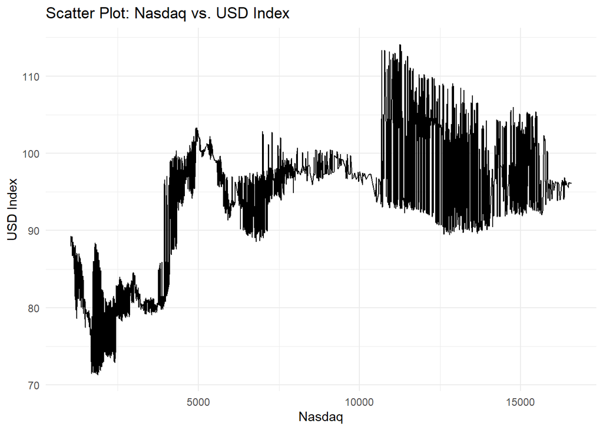

```r
library(ggplot2)
ggplot(merge_Nasdaq_USDIndex, aes(x = Price.x, y = Price.y)) +
  geom_line() +
  labs(
    title = "Scatter Plot: Nasdaq vs. USD Index",
    x = "Nasdaq",
    y = "USD Index"
  ) +
  theme_minimal()
```

Next, we compared the historical price data of Nasdaq and the S&P 500 index. By plotting their prices over time, we observed trends and fluctuations in both indices.

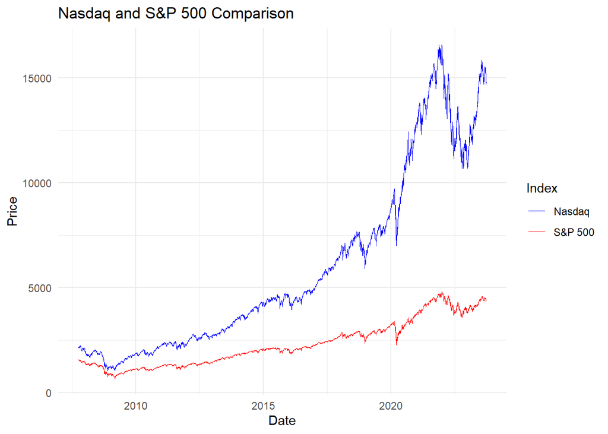

```r
library(ggplot2)
ggplot() +
  geom_line(data = Nasdaq, aes(x = Date, y = Price, color = "Nasdaq"), size = 0.25) +
  geom_line(data = SP500, aes(x = Date, y = Price, color = "S&P 500"), size = 0.25) +
  labs(
    title = "Nasdaq and S&P 500 Comparison",
    x = "Date",
    y = "Price",
    color = "Index"
  ) +
  scale_color_manual(values = c("Nasdaq" = "blue", "S&P 500" = "red")) +
  theme_minimal()
```

```r
cor(Nasdaq$Price,SP500$Price)
```

```
## [1] 0.988213
```

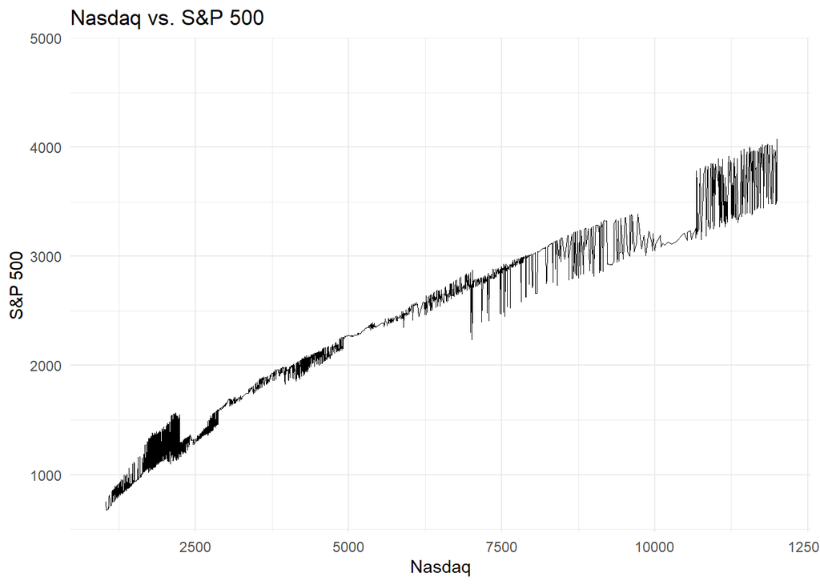

```r
# Create a scatter plot
plot=
ggplot() +
  geom_line(data = Nasdaq, aes(x = Nasdaq$Price, y = SP500$Price), size = .25) +
  labs(
    title = "Nasdaq vs. S&P 500",
    x = "Nasdaq",
    y = "S&P 500"
  ) +
  theme_minimal()
  plot + scale_x_continuous(limits = c(1000, 12000))
```

US 10 year Yield: The 10 Year Treasury Rate is the yield received for investing in a US government issued treasury security that has a maturity of 10 year.

#US10yearbond

```r
US10Yearbond=read.csv("C:/Users/gpras/Downloads/United States 10-Year Bond Yield Historical Data (1).csv")
US10Yearbond$Date <- as.Date(US10Yearbond$Date, format = "%m/%d/%Y")
US10Yearbond=US10Yearbond[rev(1:nrow(US10Yearbond)), ]
str(US10Yearbond)
```

```
## 'data.frame':    4158 obs. of  6 variables:
##  $ Date    : Date, format: "2007-10-01" "2007-10-02" ...
##  $ Price   : num  4.55 4.53 4.56 4.52 4.64 ...
##  $ Open    : num  4.55 4.53 4.56 4.52 4.64 ...
##  $ High    : num  4.55 4.53 4.56 4.52 4.64 ...
##  $ Low     : num  4.55 4.53 4.56 4.52 4.64 ...
##  $ Change..: chr  "-0.98%" "-0.48%" "0.75%" "-0.99%" ...
```

```r
str(Nasdaq)
```

```
## 'data.frame':    4024 obs. of  7 variables:
##  $ Date    : Date, format: "2007-10-01" "2007-10-02" ...
##  $ Price   : num  2117 2116 2103 2106 2150 ...
##  $ Open    : chr  "2,092.60" "2,116.15" "2,108.04" "2,107.11" ...
##  $ High    : chr  "2,120.79" "2,117.34" "2,117.38" "2,107.72" ...
##  $ Low     : chr  "2,092.60" "2,104.15" "2,095.30" "2,088.79" ...
##  $ Vol.    : chr  "371.74M" "299.55M" "321.37M" "302.30M" ...
##  $ Change..: chr  "1.24%" "-0.05%" "-0.61%" "0.12%" ...
```

```r
#USA stock index and US10year bond
merge_Nasdaq_USB <- merge(Nasdaq, US10Yearbond, by = "Date")
correlation_Nasdaq_USB <- cor(merge_Nasdaq_USB$Price.x,merge_Nasdaq_USB$Price.y)
correlation_Nasdaq_USB
```

```
## [1] -0.271183
```

```r
#Correlation between USA index and US10year bond -0.271183
```

This code generates a scatter plot to visually explore and understand the relationship between the USA stock index (Nasdaq) and the US 10-Year Bond. By connecting data points with lines, this plot allows you to identify any patterns or trends that may exist between these two financial instruments. It can help you assess whether there is any correlation or influence between the movements of the stock index and the bond yield.

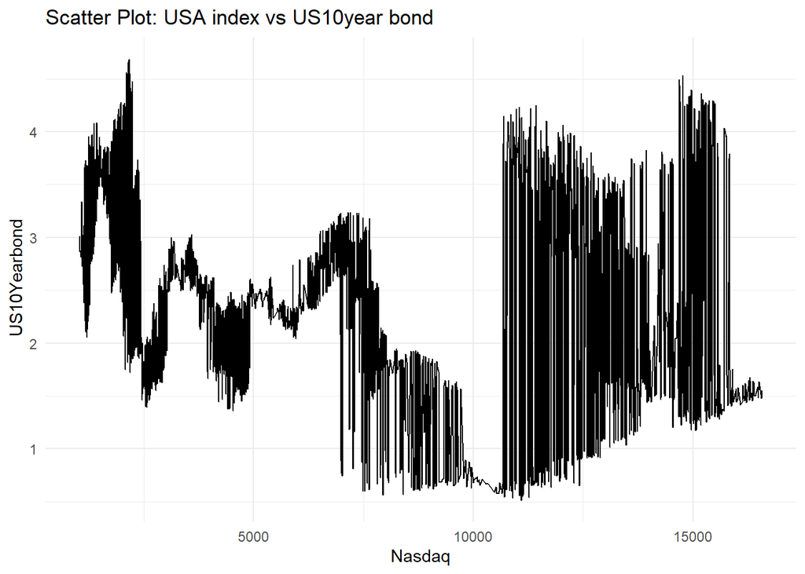

```r
# scatterplot between USA index and US10year bond
library(ggplot2)
Nasdaq_USB_plot <-
ggplot(merge_Nasdaq_USB, aes(x = Price.x, y = Price.y)) +
  geom_line() +
  labs(
    title = "Scatter Plot: USA index vs US10year bond",
    x = "Nasdaq",
    y = " US10Yearbond"
  ) +
  theme_minimal()
Nasdaq_USB_plot
```

This composite plot is designed to provide a side-by-side comparison of the historical price trends of the USA stock index (Nasdaq) and the US 10-Year Bond. By plotting their price movements over time on the same chart, it allows you to visually assess any patterns, trends, or potential correlations between these two financial assets. The resulting composite plot allows you to gain insights into how the Nasdaq and the US 10-Year Bond have performed over the specified time period and whether there are any observable patterns or relationships.

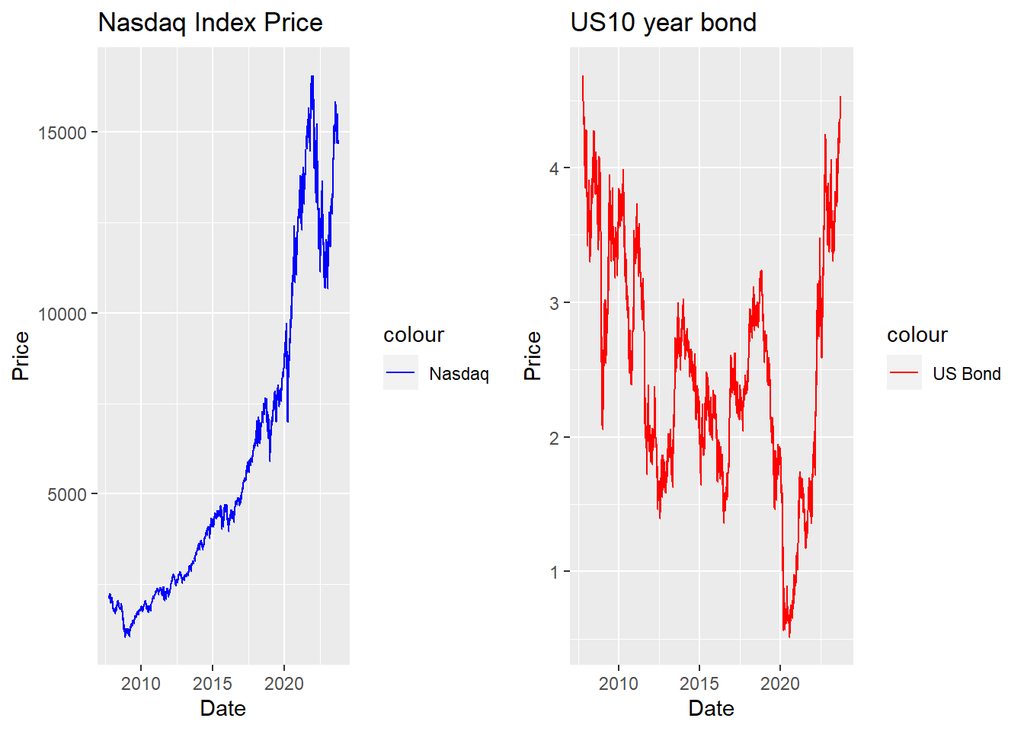

```r
#USA index vs US10year bond over time plot
library(ggplot2)
library(gridExtra)

plot_nasdaq <- ggplot(data = merge_Nasdaq_USB, aes(x = Date)) +
  geom_line(aes(y = Price.x, color = "Nasdaq")) +
  labs(x = "Date", y = "Price") +
  scale_color_manual(values = c("Nasdaq" = "blue")) +
  ggtitle("Nasdaq Index Price")
plot_USBond <- ggplot(data = merge_Nasdaq_USB, aes(x = Date)) +
  geom_line(aes(y = Price.y, color = "US Bond")) +
  labs(x = "Date", y = "Price") +
  scale_color_manual(values = c("US Bond" = "red")) +
  ggtitle("US10 year bond")
grid.arrange(plot_nasdaq, plot_USBond, ncol = 2)
```

The code aims to provide a side-by-side visual comparison of the historical price trends of the USA stock index (Nasdaq) and the US 10-Year Bond specifically within the defined date range. This allows for an in-depth examination of how these financial assets have performed and interacted during the specified time period. Analyzing financial data within a specific time frame is crucial for assessing the performance of assets and understanding potential correlations or trends. This type of composite plot is valuable in making informed financial decisions and researching the relationship between stock market movements and bond yields. The resulting composite plot presents insights into the price trends of Nasdaq and the US 10-Year Bond over the chosen time period, helping you assess their performance and interactions within this specific date range.

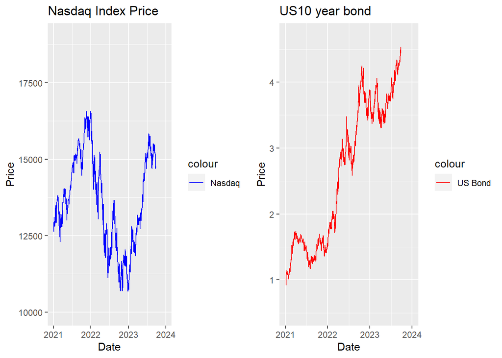

```r
#within a particular period
start_date <- as.Date("2021-01-01")
end_date <- as.Date("2023-12-31")
y_limits <- c(10000, 19000)
#USA index vs US10year bond over time plot
library(ggplot2)
library(gridExtra)

plot_nasdaq <- ggplot(data = merge_Nasdaq_USB, aes(x = Date)) +
  geom_line(aes(y = Price.x, color = "Nasdaq")) +
  labs(x = "Date", y = "Price") + xlim(start_date,end_date) + ylim(y_limits)+
  scale_color_manual(values = c("Nasdaq" = "blue")) +
  ggtitle("Nasdaq Index Price")
plot_USBond <- ggplot(data = merge_Nasdaq_USB, aes(x = Date)) +
  geom_line(aes(y = Price.y, color = "US Bond")) +
  labs(x = "Date", y = "Price") + xlim(start_date,end_date) +
  scale_color_manual(values = c("US Bond" = "red")) +
  ggtitle("US10 year bond")
grid.arrange(plot_nasdaq, plot_USBond, ncol = 2)
```

[figure not shown]

```r
#within a particular period
start_date <- as.Date("2008-01-01")
end_date <- as.Date("2010-12-31")
y_limits <- c(10000, 19000)
#USA index vs US10year bond over time plot
library(ggplot2)
library(gridExtra)

plot_nasdaq <- ggplot(data = merge_Nasdaq_USB, aes(x = Date)) +
  geom_line(aes(y = Price.x, color = "Nasdaq")) +
  labs(x = "Date", y = "Price") + xlim(start_date,end_date) + ylim(y_limits)+
  scale_color_manual(values = c("Nasdaq" = "blue")) +
  ggtitle("Nasdaq Index Price")
plot_USBond <- ggplot(data = merge_Nasdaq_USB, aes(x = Date)) +
  geom_line(aes(y = Price.y, color = "US Bond")) +
  labs(x = "Date", y = "Price") + xlim(start_date,end_date) +
  scale_color_manual(values = c("US Bond" = "red")) +
  ggtitle("US10 year bond")
grid.arrange(plot_nasdaq, plot_USBond, ncol = 2)
```

## Question 2

2. What is the relationship between the performance of the Indian stock market, US stock market, Europe stock market, China stock market, japan stock market, Singapore stock market and how has this relationship evolved over the 15 years?

You started by importing historical data for stock indices and financial instruments from different countries, including India, the UK, Singapore, Russia, China, Japan, and the USA. For each dataset, you converted the date column to a standardized format, reversed the data for chronological order, and cleaned the price and volume data by removing commas and formatting them as numeric values.

```r
str(Nasdaq)
```

```
## 'data.frame':    4024 obs. of  7 variables:
##  $ Date    : Date, format: "2007-10-01" "2007-10-02" ...
##  $ Price   : num  2117 2116 2103 2106 2150 ...
##  $ Open    : chr  "2,092.60" "2,116.15" "2,108.04" "2,107.11" ...
##  $ High    : chr  "2,120.79" "2,117.34" "2,117.38" "2,107.72" ...
##  $ Low     : chr  "2,092.60" "2,104.15" "2,095.30" "2,088.79" ...
##  $ Vol.    : chr  "371.74M" "299.55M" "321.37M" "302.30M" ...
##  $ Change..: chr  "1.24%" "-0.05%" "-0.61%" "0.12%" ...
```

```r
#India
India.Index=read.csv("C:/Users/gpras/Downloads/Nifty 50 Historical Data.csv")
India.Index$Date <- as.Date(India.Index$Date, format = "%m/%d/%Y")
India.Index=India.Index[rev(1:nrow(India.Index)), ]
India.Index$Price <- as.numeric(gsub(",", "", India.Index$Price))
str(India.Index)
```

```
## 'data.frame':    3958 obs. of  7 variables:
##  $ Date    : Date, format: "2007-10-01" "2007-10-03" ...
##  $ Price   : num  5069 5211 5209 5186 5085 ...
##  $ Open    : chr  "5,021.50" "5,069.00" "5,211.65" "5,208.15" ...
##  $ High    : chr  "5,089.30" "5,261.35" "5,233.10" "5,248.55" ...
##  $ Low     : chr  "5,001.35" "5,034.15" "5,126.05" "5,164.50" ...
##  $ Vol.    : chr  "132.21B" "187.72B" "127.31B" "93.29B" ...
##  $ Change..: chr  "0.95%" "2.80%" "-0.04%" "-0.44%" ...
```

```r
#UK
UK.Index = read.csv("C:/Users/gpras/Downloads/FTSE 100 Historical Data.csv")
UK.Index$Date <- as.Date(UK.Index$Date, format = "%m/%d/%Y")
UK.Index=UK.Index[rev(1:nrow(UK.Index)), ]
UK.Index$Price <- as.numeric(gsub(",", "", UK.Index$Price))
str(UK.Index)
```

```
## 'data.frame':    4036 obs. of  7 variables:
##  $ Date    : Date, format: "2007-10-01" "2007-10-02" ...
##  $ Price   : num  6506 6500 6535 6548 6596 ...
##  $ Open    : chr  "6,466.80" "6,506.20" "6,500.40" "6,535.20" ...
##  $ High    : chr  "6,514.50" "6,567.00" "6,542.80" "6,593.30" ...
##  $ Low     : chr  "6,419.20" "6,489.60" "6,495.00" "6,507.20" ...
##  $ Vol.    : chr  "" "" "" "" ...
##  $ Change..: chr  "0.61%" "-0.09%" "0.54%" "0.19%" ...
```

```r
#Singapore
Singapore.Index = read.csv("C:/Users/gpras/Downloads/FTSE Straits Times Singapore Historical Data.csv")
Singapore.Index$Date <- as.Date(Singapore.Index$Date, format = "%m/%d/%Y")
Singapore.Index=Singapore.Index[rev(1:nrow(Singapore.Index)), ]
Singapore.Index$Price <- as.numeric(gsub(",", "", Singapore.Index$Price))
Singapore.Index <- subset(Singapore.Index, select = -Vol.)
str(Singapore.Index)
```

```
## 'data.frame':    3031 obs. of  6 variables:
##  $ Date    : Date, format: "2011-03-07" "2011-03-08" ...
##  $ Price   : num  3067 3104 3093 3075 3043 ...
##  $ Open    : chr  "3,054.43" "3,063.58" "3,110.54" "3,093.79" ...
##  $ High    : chr  "3,074.93" "3,105.90" "3,113.02" "3,094.38" ...
##  $ Low     : chr  "3,047.59" "3,062.52" "3,087.84" "3,070.55" ...
##  $ Change..: chr  "0.17%" "1.22%" "-0.35%" "-0.56%" ...
```

```r
#russia
Russia.Index= read.csv("C:/Users/gpras/Downloads/MOEX Russia Historical Data.csv")
Russia.Index$Date <- as.Date(Russia.Index$Date, format = "%m/%d/%Y")
Russia.Index=Russia.Index[rev(1:nrow(Russia.Index)), ]
Russia.Index$Price <- as.numeric(gsub(",", "", Russia.Index$Price))
Russia.Index <- subset(Russia.Index, select = -Vol.)
str(Russia.Index)
```

```
## 'data.frame':    4001 obs. of  6 variables:
##  $ Date    : Date, format: "2007-10-01" "2007-10-02" ...
##  $ Price   : num  1733 1795 1779 1778 1802 ...
##  $ Open    : chr  "1,759.44" "1,733.41" "1,795.06" "1,778.64" ...
##  $ High    : chr  "1,759.44" "1,796.20" "1,806.90" "1,786.12" ...
##  $ Low     : chr  "1,724.32" "1,733.39" "1,773.80" "1,767.29" ...
##  $ Change..: chr  "-1.48%" "3.56%" "-0.91%" "-0.05%" ...
```

```r
#china
China.Index= read.csv("C:/Users/gpras/Downloads/Shanghai Composite Historical Data.csv")
China.Index$Date <- as.Date(China.Index$Date, format = "%m/%d/%Y")
China.Index=China.Index[rev(1:nrow(China.Index)), ]
China.Index$Price <- as.numeric(gsub(",", "", China.Index$Price))
str(China.Index)
```

[output not shown]

```r
#Japan
Japan.Index= read.csv("C:/Users/gpras/Downloads/Nikkei 225 Historical Data.csv")
Japan.Index$Date <- as.Date(Japan.Index$Date, format = "%m/%d/%Y")
Japan.Index=Japan.Index[rev(1:nrow(Japan.Index)), ]
Japan.Index$Price <- as.numeric(gsub(",", "", Japan.Index$Price))
str(Japan.Index)
```

```
## 'data.frame':    3937 obs. of  7 variables:
##  $ Date    : Date, format: "2007-10-01" "2007-10-02" ...
##  $ Price   : num  16846 17047 17200 17092 17065 ...
##  $ Open    : chr  "16,773.10" "17,027.92" "17,066.14" "17,085.32" ...
##  $ High    : chr  "16,899.84" "17,072.67" "17,205.42" "17,160.47" ...
##  $ Low     : chr  "16,685.80" "16,986.38" "17,017.77" "17,043.76" ...
##  $ Vol.    : chr  "" "" "" "" ...
##  $ Change..: chr  "0.36%" "1.19%" "0.90%" "-0.62%" ...
```

```r
#The resulting correlation coefficient, stored in correlation_IndiaUSA, provides a quantitative measure of the relationship between the Nasdaq index and the Nifty 50 Index, indicating whether they tend to move together or diverge over time.

#India vs USA
merge_Nasdaq_India <- merge(Nasdaq, India.Index, by = "Date")
correlation_IndiaUSA <- cor(merge_Nasdaq_India$Price.x,merge_Nasdaq_India$Price.y)
correlation_IndiaUSA
```

```
## [1] 0.9643381
```

```r
str(merge_Nasdaq_India)
```

```
## 'data.frame':    3831 obs. of  13 variables:
##  $ Date      : Date, format: "2007-10-01" "2007-10-03" ...
##  $ Price.x   : num  2117 2103 2106 2150 2163 ...
##  $ Open.x    : chr  "2,092.60" "2,108.04" "2,107.11" "2,123.49" ...
##  $ High.x    : chr  "2,120.79" "2,117.38" "2,107.72" "2,151.72" ...
##  $ Low.x     : chr  "2,092.60" "2,095.30" "2,088.79" "2,118.13" ...
##  $ Vol..x    : chr  "371.74M" "321.37M" "302.30M" "376.89M" ...
##  $ Change...x: chr  "1.24%" "-0.61%" "0.12%" "2.09%" ...
##  $ Price.y   : num  5069 5211 5209 5186 5085 ...
##  $ Open.y    : chr  "5,021.50" "5,069.00" "5,211.65" "5,208.15" ...
##  $ High.y    : chr  "5,089.30" "5,261.35" "5,233.10" "5,248.55" ...
##  $ Low.y     : chr  "5,001.35" "5,034.15" "5,126.05" "5,164.50" ...
##  $ Vol..y    : chr  "132.21B" "187.72B" "127.31B" "93.29B" ...
##  $ Change...y: chr  "0.95%" "2.80%" "-0.04%" "-0.44%" ...
```

```r
str(India.Index)
```

```
## 'data.frame':    3958 obs. of  7 variables:
##  $ Date    : Date, format: "2007-10-01" "2007-10-03" ...
##  $ Price   : num  5069 5211 5209 5186 5085 ...
##  $ Open    : chr  "5,021.50" "5,069.00" "5,211.65" "5,208.15" ...
##  $ High    : chr  "5,089.30" "5,261.35" "5,233.10" "5,248.55" ...
##  $ Low     : chr  "5,001.35" "5,034.15" "5,126.05" "5,164.50" ...
##  $ Vol.    : chr  "132.21B" "187.72B" "127.31B" "93.29B" ...
##  $ Change..: chr  "0.95%" "2.80%" "-0.04%" "-0.44%" ...
```

```r
str(Nasdaq)
```

```
## 'data.frame':    4024 obs. of  7 variables:
##  $ Date    : Date, format: "2007-10-01" "2007-10-02" ...
##  $ Price   : num  2117 2116 2103 2106 2150 ...
##  $ Open    : chr  "2,092.60" "2,116.15" "2,108.04" "2,107.11" ...
##  $ High    : chr  "2,120.79" "2,117.34" "2,117.38" "2,107.72" ...
##  $ Low     : chr  "2,092.60" "2,104.15" "2,095.30" "2,088.79" ...
##  $ Vol.    : chr  "371.74M" "299.55M" "321.37M" "302.30M" ...
##  $ Change..: chr  "1.24%" "-0.05%" "-0.61%" "0.12%" ...
```

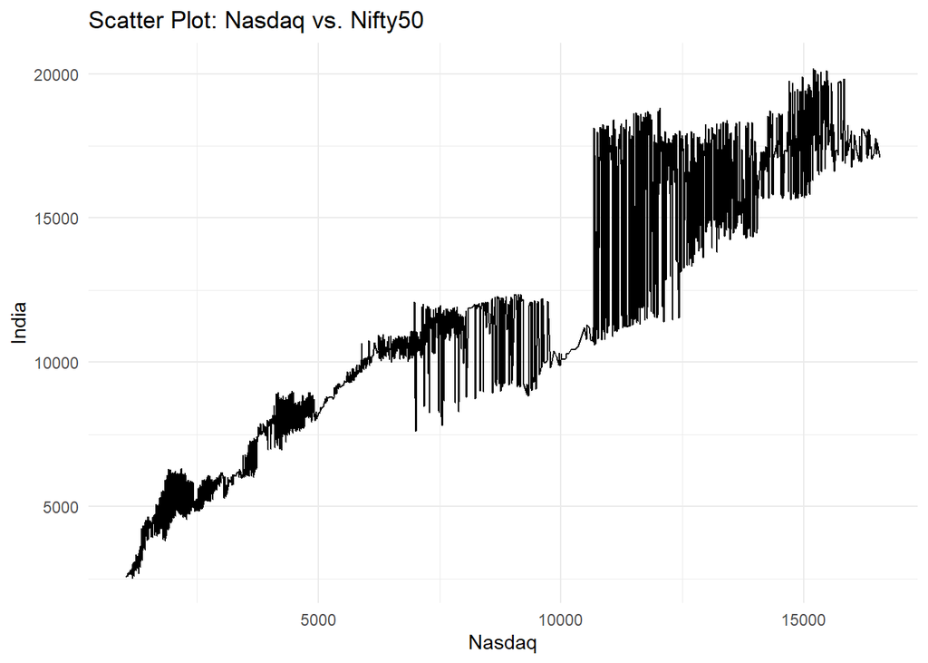

```r
#correlation between India and USA is 0.9643381


#scatterplot between India Index and USA Index
library(ggplot2)
India_USA_plot <-
ggplot(merge_Nasdaq_India, aes(x = Price.x, y = Price.y)) +
  geom_line() +
  labs(
    title = "Scatter Plot: Nasdaq vs. Nifty50",
    x = "Nasdaq",
    y = "India"
  ) +
  theme_minimal()
India_USA_plot
```

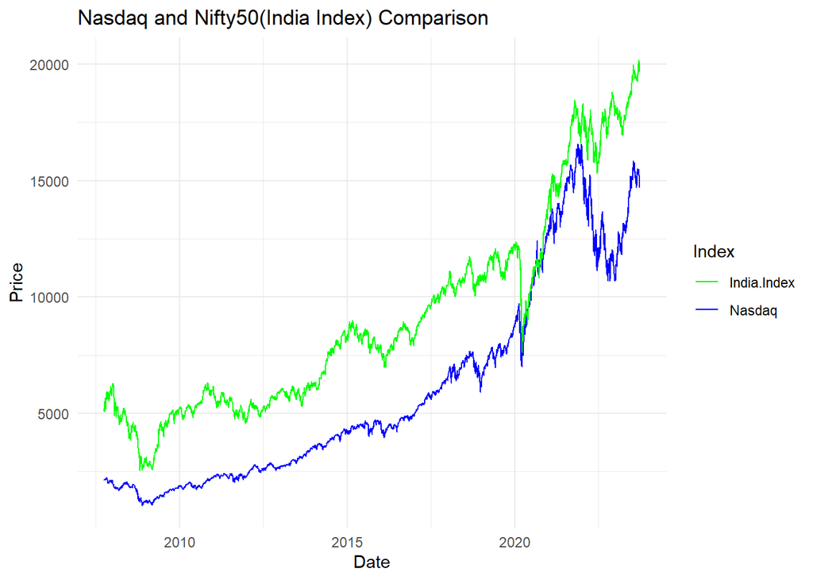

```r
#Nifty 50 and Nasdaq over time Plot


library(ggplot2)

ggplot() +
  geom_line(data = Nasdaq, aes(x = Date, y = Price, color = "Nasdaq"), size = 0.5) +
  geom_line(data = India.Index, aes(x = Date, y = Price, color = "India.Index"), size = 0.5) +
  labs(
    title = "Nasdaq and Nifty50(India Index) Comparison",
    x = "Date",
    y = "Price",
    color = "Index"
  ) +
  scale_color_manual(values = c("Nasdaq" = "Blue", "India.Index" = "Green")) +
  theme_minimal()
```

#Nifty 50 and Nasdaq over time Plot This visually represent the relationship or correlation between two major stock indices: the Nasdaq (USA) and the Nifty 50 (India). A scatter plot is an effective way to assess the degree of correlation or divergence between these indices. By connecting data points with lines, it allows you to identify patterns and trends in their movements over time.

The resulting scatter plot, India_USA_plot, visually represents the data points for the Nasdaq and Nifty 50 indices, allowing for an assessment of their relationship and performance over time. This visually compare the historical price trends of two significant stock indices: the Nasdaq (USA) and the Nifty 50 (India). By displaying these trends over time in a single plot, it allows for a direct comparison of how these indices have performed in relation to each other. Time series plots like this one are commonly used in financial analysis to assess the performance of different stock indices or assets. They are useful for identifying trends, patterns, and potential correlations between indices from different regions. This type of analysis can be valuable for investors and analysts seeking international diversification or researching global market trends.

The resulting time series plot provides a clear visual representation of how the Nasdaq and the Nifty 50 have evolved over time, making it easier to draw insights and comparisons between these two major indices.

```r
#Uk vs USA
str(UK.Index)
```

```
## 'data.frame':    4036 obs. of  7 variables:
##  $ Date    : Date, format: "2007-10-01" "2007-10-02" ...
##  $ Price   : num  6506 6500 6535 6548 6596 ...
##  $ Open    : chr  "6,466.80" "6,506.20" "6,500.40" "6,535.20" ...
##  $ High    : chr  "6,514.50" "6,567.00" "6,542.80" "6,593.30" ...
##  $ Low     : chr  "6,419.20" "6,489.60" "6,495.00" "6,507.20" ...
##  $ Vol.    : chr  "" "" "" "" ...
##  $ Change..: chr  "0.61%" "-0.09%" "0.54%" "0.19%" ...
```

```r
str(Nasdaq)
```

```
## 'data.frame':    4024 obs. of  7 variables:
##  $ Date    : Date, format: "2007-10-01" "2007-10-02" ...
##  $ Price   : num  2117 2116 2103 2106 2150 ...
##  $ Open    : chr  "2,092.60" "2,116.15" "2,108.04" "2,107.11" ...
##  $ High    : chr  "2,120.79" "2,117.34" "2,117.38" "2,107.72" ...
##  $ Low     : chr  "2,092.60" "2,104.15" "2,095.30" "2,088.79" ...
##  $ Vol.    : chr  "371.74M" "299.55M" "321.37M" "302.30M" ...
##  $ Change..: chr  "1.24%" "-0.05%" "-0.61%" "0.12%" ...
```

```r
merge_Nasdaq_UK <- merge(Nasdaq, UK.Index, by = "Date")
str(merge_Nasdaq_UK)
```

```
## 'data.frame':    3948 obs. of  13 variables:
##  $ Date      : Date, format: "2007-10-01" "2007-10-02" ...
##  $ Price.x   : num  2117 2116 2103 2106 2150 ...
##  $ Open.x    : chr  "2,092.60" "2,116.15" "2,108.04" "2,107.11" ...
##  $ High.x    : chr  "2,120.79" "2,117.34" "2,117.38" "2,107.72" ...
##  $ Low.x     : chr  "2,092.60" "2,104.15" "2,095.30" "2,088.79" ...
##  $ Vol..x    : chr  "371.74M" "299.55M" "321.37M" "302.30M" ...
##  $ Change...x: chr  "1.24%" "-0.05%" "-0.61%" "0.12%" ...
##  $ Price.y   : num  6506 6500 6535 6548 6596 ...
##  $ Open.y    : chr  "6,466.80" "6,506.20" "6,500.40" "6,535.20" ...
##  $ High.y    : chr  "6,514.50" "6,567.00" "6,542.80" "6,593.30" ...
##  $ Low.y     : chr  "6,419.20" "6,489.60" "6,495.00" "6,507.20" ...
##  $ Vol..y    : chr  "" "" "" "" ...
##  $ Change...y: chr  "0.61%" "-0.09%" "0.54%" "0.19%" ...
```

```r
correlation_UKUSA <- cor(merge_Nasdaq_UK$Price.x,merge_Nasdaq_UK$Price.y)
correlation_UKUSA
```

```
## [1] 0.6578211
```

#correlation between Uk and USA is just 0.657

This visually represent the relationship or correlation between two significant stock indices: the Nasdaq (USA) and the UK Index (FTSE). The resulting scatter plot, UK_USA_plot, visually represents the data points for the Nasdaq and the UK Index, allowing for an assessment of their relationship and performance over time.

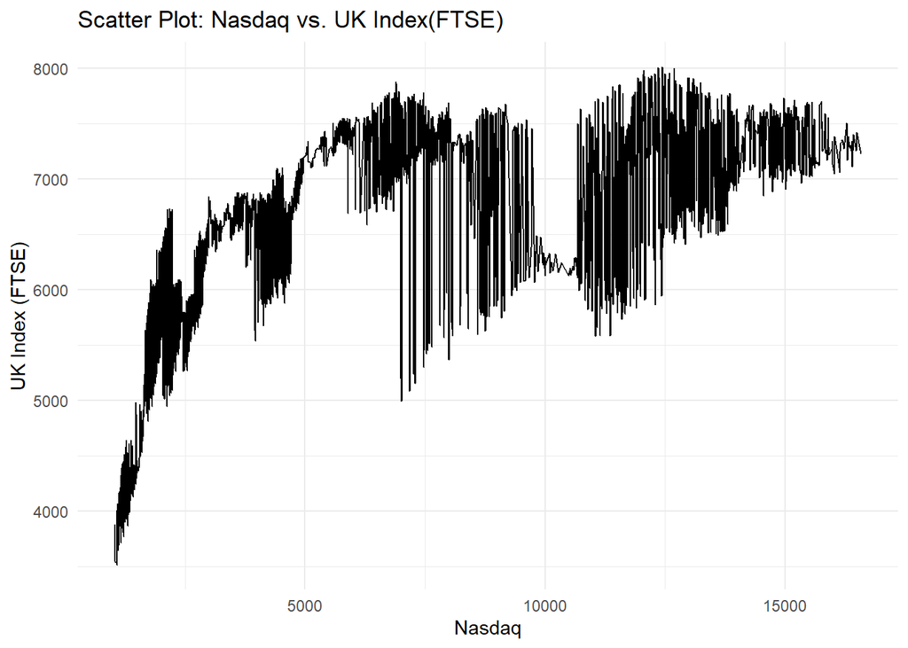

```r
#scatterplot between India Index and USA Index
library(ggplot2)
UK_USA_plot <-
ggplot(merge_Nasdaq_UK, aes(x = Price.x, y = Price.y)) +
  geom_line() +
  labs(
    title = "Scatter Plot: Nasdaq vs. UK Index(FTSE)",
    x = "Nasdaq",
    y = "UK Index (FTSE)"
  ) +
  theme_minimal()
UK_USA_plot
```

The resulting time series plot, UKIndexandNasdaqovertimePlot, provides a clear visual representation of how the Nasdaq and the FTSE 100 Index have evolved over time, making it easier to draw insights and comparisons between these two major indices.

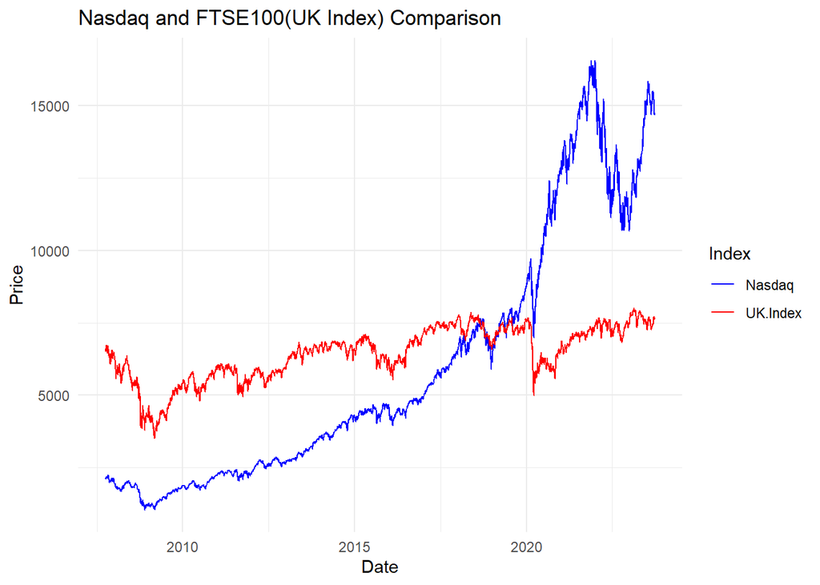

```r
UKIndexandNasdaqovertimePlot <-
ggplot() +
  geom_line(data = Nasdaq, aes(x = Date, y = Price, color = "Nasdaq"), size = 0.5) +
  geom_line(data = UK.Index, aes(x = Date, y = Price, color = "UK.Index"), size = 0.5) +
  labs(
    title = "Nasdaq and FTSE100(UK Index) Comparison",
    x = "Date",
    y = "Price",
    color = "Index"
  ) +
  scale_color_manual(values = c("Nasdaq" = "Blue", "UK.Index" = "Red")) +
  theme_minimal()
UKIndexandNasdaqovertimePlot
```

```r
#UK Index and Nasdaq over time Plot
```

# USA vs Russia

```r
merge_Nasdaq_Russia <- merge(Nasdaq, Russia.Index, by = "Date")
correlation_USA_Russia <- cor(merge_Nasdaq_Russia$Price.x,merge_Nasdaq_Russia$Price.y)
correlation_USA_Russia
```

```
## [1] 0.8921153
```

The resulting scatter plot, Scatter_Nasdaq_Russia_plot, visually represents the data points for the Nasdaq and the Russia Index, allowing for an assessment of their relationship and performance over time.

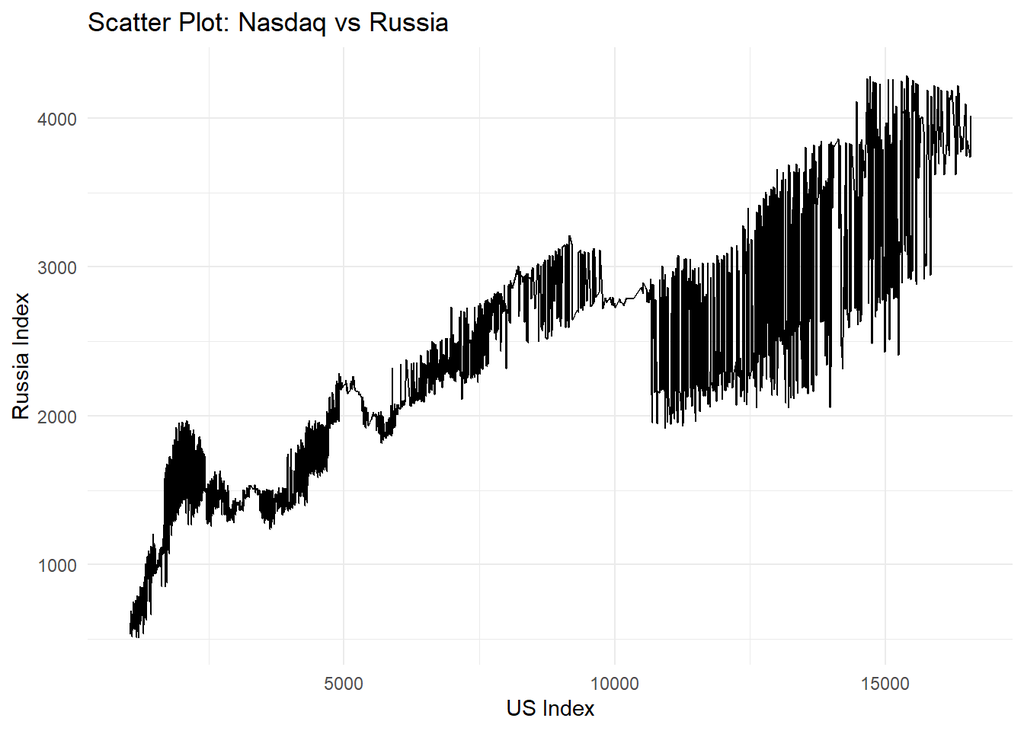

```r
# Scattler plot between Russia Index and USA Index
Scatter_Nasdaq_Russia_plot <-
ggplot(merge_Nasdaq_Russia, aes(x = Price.x, y = Price.y)) +
  geom_line() +
  labs(
    title = "Scatter Plot: Nasdaq vs Russia",
    x = "US Index",
    y = "Russia Index"
  ) +
  theme_minimal()
Scatter_Nasdaq_Russia_plot
```

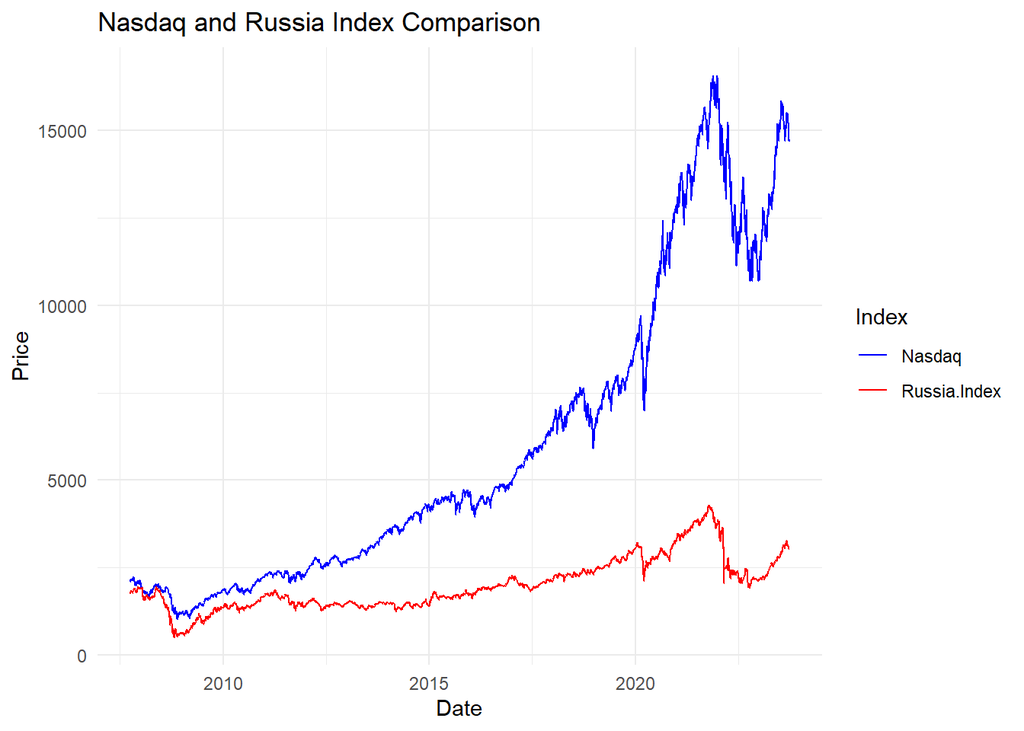

```r
# over timeplot between USA and Russia
library(ggplot2)

ggplot() +
  geom_line(data = Nasdaq, aes(x = Date, y = Price, color = "Nasdaq"), size = 0.5) +
  geom_line(data = Russia.Index, aes(x = Date, y = Price, color = "Russia.Index"), size = 0.5) +
  labs(
    title = "Nasdaq and Russia Index Comparison",
    x = "Date",
    y = "Price",
    color = "Index"
  ) +
  scale_color_manual(values = c("Nasdaq" = "Blue", "Russia.Index" = "Red")) +
  theme_minimal()
```

```r
#Singapore vs USA

str(UK.Index)
```

```
## 'data.frame':    4036 obs. of  7 variables:
##  $ Date    : Date, format: "2007-10-01" "2007-10-02" ...
##  $ Price   : num  6506 6500 6535 6548 6596 ...
##  $ Open    : chr  "6,466.80" "6,506.20" "6,500.40" "6,535.20" ...
##  $ High    : chr  "6,514.50" "6,567.00" "6,542.80" "6,593.30" ...
##  $ Low     : chr  "6,419.20" "6,489.60" "6,495.00" "6,507.20" ...
##  $ Vol.    : chr  "" "" "" "" ...
##  $ Change..: chr  "0.61%" "-0.09%" "0.54%" "0.19%" ...
```

```r
str(Nasdaq)
```

```
## 'data.frame':    4024 obs. of  7 variables:
##  $ Date    : Date, format: "2007-10-01" "2007-10-02" ...
##  $ Price   : num  2117 2116 2103 2106 2150 ...
##  $ Open    : chr  "2,092.60" "2,116.15" "2,108.04" "2,107.11" ...
##  $ High    : chr  "2,120.79" "2,117.34" "2,117.38" "2,107.72" ...
##  $ Low     : chr  "2,092.60" "2,104.15" "2,095.30" "2,088.79" ...
##  $ Vol.    : chr  "371.74M" "299.55M" "321.37M" "302.30M" ...
##  $ Change..: chr  "1.24%" "-0.05%" "-0.61%" "0.12%" ...
```

```r
merge_Nasdaq_Singapore <- merge(Nasdaq, Singapore.Index, by = "Date")
str(merge_Nasdaq_Singapore)
```

```
## 'data.frame':    2947 obs. of  12 variables:
##  $ Date      : Date, format: "2011-03-07" "2011-03-08" ...
##  $ Price.x   : num  2328 2338 2323 2284 2299 ...
##  $ Open.x    : chr  "2,367.92" "2,325.13" "2,328.80" "2,295.09" ...
##  $ High.x    : chr  "2,370.91" "2,347.51" "2,330.68" "2,300.53" ...
##  $ Low.x     : chr  "2,307.39" "2,310.96" "2,309.28" "2,276.12" ...
##  $ Vol.      : chr  "243.47M" "189.35M" "200.99M" "260.18M" ...
##  $ Change...x: chr  "-1.35%" "0.41%" "-0.64%" "-1.65%" ...
##  $ Price.y   : num  3067 3104 3093 3075 3043 ...
##  $ Open.y    : chr  "3,054.43" "3,063.58" "3,110.54" "3,093.79" ...
##  $ High.y    : chr  "3,074.93" "3,105.90" "3,113.02" "3,094.38" ...
##  $ Low.y     : chr  "3,047.59" "3,062.52" "3,087.84" "3,070.55" ...
##  $ Change...y: chr  "0.17%" "1.22%" "-0.35%" "-0.56%" ...
```

```r
correlation_USA_Singapore <- cor(merge_Nasdaq_Singapore$Price.x,merge_Nasdaq_Singapore$Price.y)
correlation_USA_Singapore
```

```
## [1] 0.209974
```

#correlation between Singapore vs USA is just 0.209974

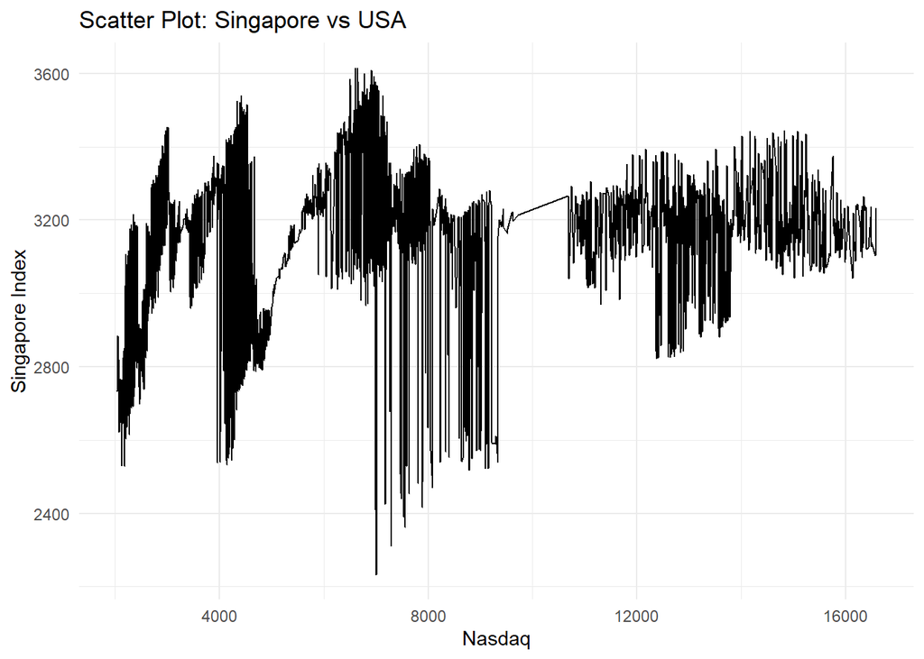

```r
#scatterplot between India Index and USA Index
library(ggplot2)
Singapore_USA_plot <-
ggplot(merge_Nasdaq_Singapore, aes(x = Price.x, y = Price.y)) +
  geom_line() +
  labs(
    title = "Scatter Plot: Singapore vs USA",
    x = "Nasdaq",
    y = "Singapore Index"
  ) +
  theme_minimal()
Singapore_USA_plot
```

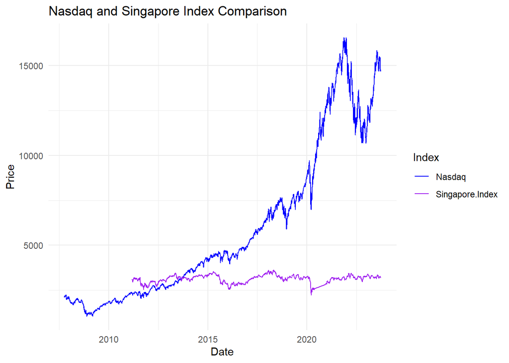

```r
SingaporeandNasdaqovertimePlot <-
ggplot() +
  geom_line(data = Nasdaq, aes(x = Date, y = Price, color = "Nasdaq"), size = 0.5) +
  geom_line(data = Singapore.Index, aes(x = Date, y = Price, color = "Singapore.Index"), size = 0.5) +
  labs(
    title = "Nasdaq and Singapore Index Comparison",
    x = "Date",
    y = "Price",
    color = "Index"
  ) +
  scale_color_manual(values = c("Nasdaq" = "Blue", "Singapore.Index" = "Purple")) +
  theme_minimal()
SingaporeandNasdaqovertimePlot
```

```r
#Nasdaq and Singapore Index over time Plot
```

#India vs UK

```r
merged_India_UK= merge(India.Index, UK.Index, by = "Date")
correlation_IndiaUK <- cor(merged_India_UK$Price.x,merged_India_UK$Price.y)
correlation_IndiaUK
```

```
## [1] 0.7545764
```

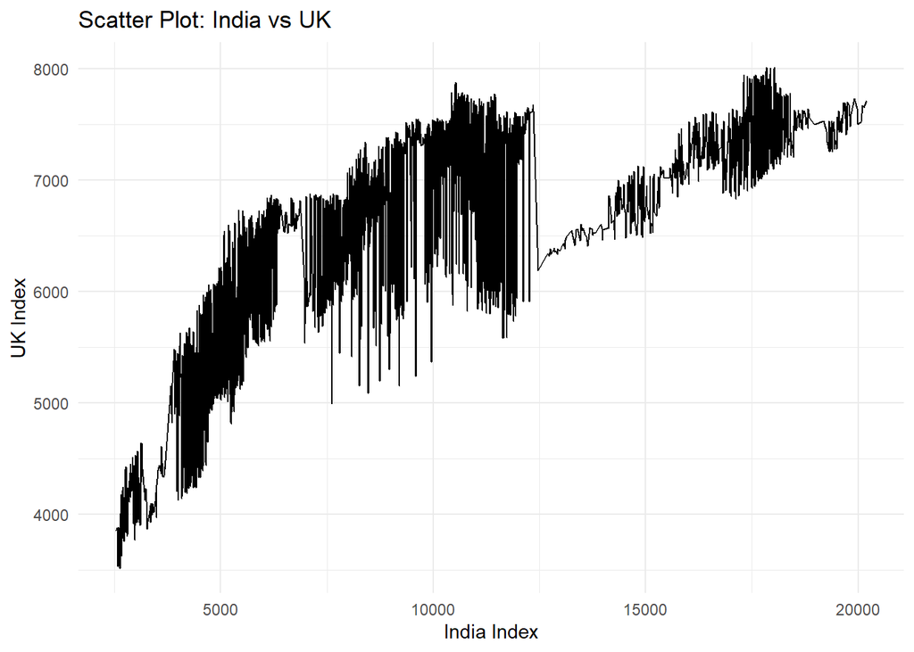

```r
#scatterplot between India Index and UK Index
library(ggplot2)
IndiaEurope_plot <-
ggplot(merged_India_UK, aes(x = Price.x, y = Price.y)) +
  geom_line() +
  labs(
    title = "Scatter Plot: India vs UK",
    x = "India Index",
    y = "UK Index"
  ) +
  theme_minimal()
IndiaEurope_plot
```

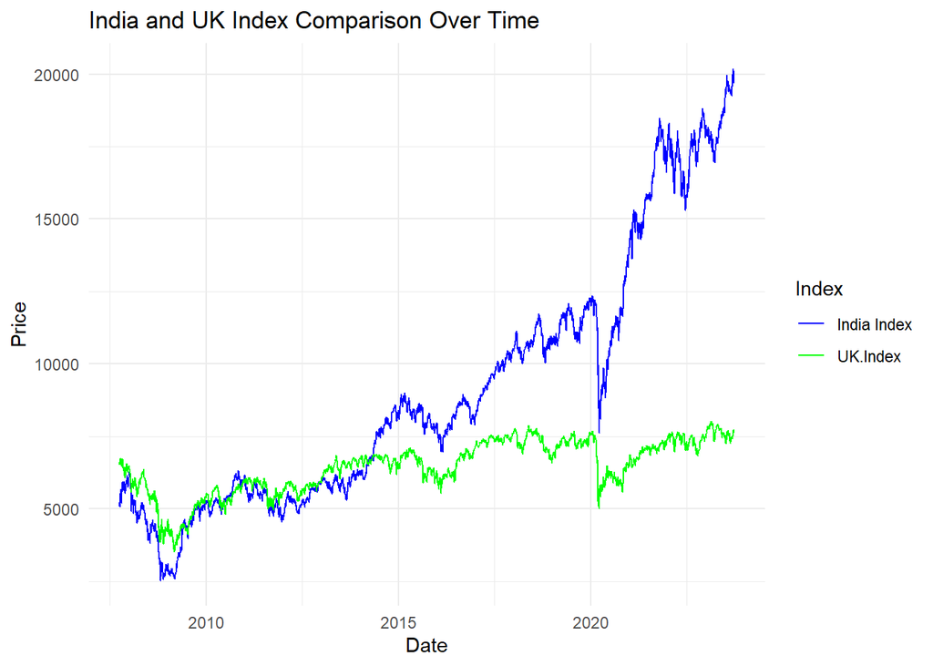

```r
#Correlation between India Index and Europe Index is  0.7545764

IndiaEuropeovertimePlot <-
ggplot() +
  geom_line(data = India.Index, aes(x = Date, y = Price, color = "India Index"), size = 0.5) +
  geom_line(data = UK.Index, aes(x = Date, y = Price, color = "UK.Index"), size = 0.5) +
  labs(
    title = "India and UK Index Comparison Over Time",
    x = "Date",
    y = "Price",
    color = "Index"
  ) +
  scale_color_manual(values = c("India Index" = "Blue", "UK.Index" = "Green")) +
  theme_minimal()
IndiaEuropeovertimePlot
```

```r
#India and UK Index over time Plot
```

```r
#India vs Singapore
merged_India_Singapore= merge(India.Index, Singapore.Index, by = "Date")
correlation_India_Singapore <- cor(merged_India_Singapore$Price.x,merged_India_Singapore$Price.y)
correlation_India_Singapore
```

```
## [1] 0.3059829
```

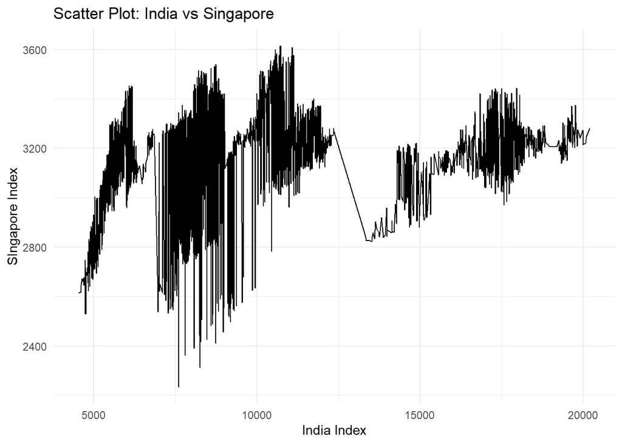

```r
#scatterplot between India Index and Singapore Index
library(ggplot2)
IndiaSingapore_plot <-
ggplot(merged_India_Singapore, aes(x = Price.x, y = Price.y)) +
  geom_line() +
  labs(
    title = "Scatter Plot: India vs Singapore",
    x = "India Index",
    y = "SIngapore Index"
  ) +
  theme_minimal()
IndiaSingapore_plot
```

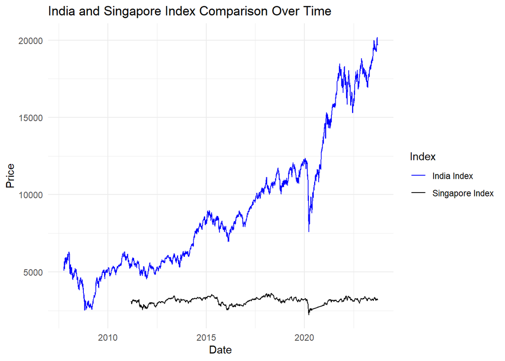

```r
#Correlation between India Index and Singapore Index is 0.3059829

IndiaSingaporeovertimePlot <- ggplot() +
  geom_line(data = India.Index, aes(x = Date, y = Price, color = "India Index"), size = 0.5) +
  geom_line(data = Singapore.Index, aes(x = Date, y = Price, color = "Singapore Index"), size = 0.5) +
  labs(
    title = "India and Singapore Index Comparison Over Time",
    x = "Date",
    y = "Price",
    color = "Index"
  ) +
  scale_color_manual(values = c("India Index" = "Blue", "Singapore Index" = "Black")) +
  theme_minimal()

print(IndiaSingaporeovertimePlot)
```

```r
#Overtimeplots for all indexes
overtimePlot <- ggplot() +
  geom_line(data = India.Index, aes(x = Date, y = Price, color = "India Index"), size = 0.5) +
  geom_line(data = UK.Index, aes(x = Date, y = Price, color = "UK Index"), size = 0.5) +
  geom_line(data = Nasdaq, aes(x = Date, y = Price, color = "US Index"), size = 0.5)+
  geom_line(data = Singapore.Index, aes(x = Date, y = Price, color = "Singapore Index"), size = 0.5)+
  geom_line(data = Russia.Index, aes(x = Date, y = Price, color = "Russia Index"), size = 0.5)


  labs(
    title = "Comparision of Various Countries Indexes Over Time",
    x = "Date",
    y = "Price",
    color = "Index"
  ) +
  scale_color_manual(values = c("India Index" = "Green", "UK Index" = "Blue","US Index"= "Red", "Singapore Index" = "black","Russia Index" = "Black")) +
  theme_minimal()
```

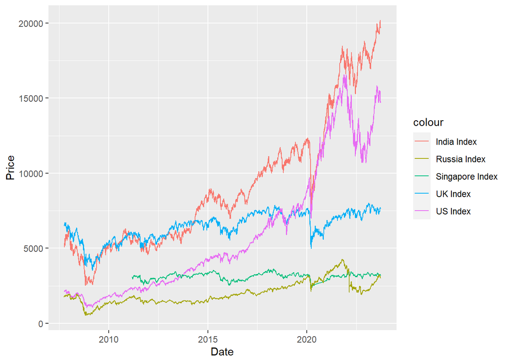

```r
overtimePlot
```

We calculate the correlation coefficients between the stock indices of different countries. For example, you calculate the correlation between India and the UK, India and Singapore, and USA (Nasdaq) and Russia. We create scatter plots to visualize the relationships between stock indices. These scatter plots provide a graphical representation of how these indices are related. We create time series plots to compare the historical price trends of stock indices over time. This allows for a visual comparison of how these indices have performed in relation to each other. The code segment concludes by creating an overall comparison plot that combines multiple stock indices from different countries. This plot aims to provide a comprehensive view of how these indices have performed over time. The purpose of this question is to conduct a comparative analysis of stock indices from various countries, allowing you to identify correlations and trends in their performance. This analysis can be valuable for investors and analysts interested in understanding how global stock markets are interconnected and how different countries’ economic and political factors influence their respective indices.

# Question 3

In question 3, we have conducted an analysis of correlations between various cryptocurrency indices and traditional stock indices.

```r
#question3
#BTC
BTC.Index=read.csv("C:/Users/gpras/Downloads/BTC_USD Bitfinex Historical Data.csv")
BTC.Index$Date <- as.Date(BTC.Index$Date, format = "%m/%d/%Y")
BTC.Index=BTC.Index[rev(1:nrow(BTC.Index)), ]
BTC.Index$Price <- as.numeric(gsub(",", "", BTC.Index$Price))
str(BTC.Index)
```

```
## 'data.frame':    4250 obs. of  7 variables:
##  $ Date    : Date, format: "2012-02-02" "2012-02-03" ...
##  $ Price   : num  6.1 6 5.9 5.7 5.4 5.7 5.6 5.8 5.9 5.6 ...
##  $ Open    : chr  "6.1" "6.0" "5.9" "5.7" ...
##  $ High    : chr  "6.1" "6.0" "5.9" "5.7" ...
##  $ Low     : chr  "6.1" "6.0" "5.9" "5.7" ...
##  $ Vol.    : chr  "" "" "" "" ...
##  $ Change..: chr  "0.00%" "-2.30%" "-1.51%" "-3.07%" ...
```

```r
# Ethereum

ETH.Index=read.csv("C:/Users/gpras/Downloads/Ethereum Historical Data.csv")
ETH.Index$Date <- as.Date(ETH.Index$Date, format = "%m/%d/%Y")
ETH.Index=ETH.Index[rev(1:nrow(ETH.Index)), ]
ETH.Index$Price <- as.numeric(gsub(",", "", ETH.Index$Price))
str(ETH.Index)
```

```
## 'data.frame':    2756 obs. of  7 variables:
##  $ Date    : Date, format: "2016-03-10" "2016-03-11" ...
##  $ Price   : num  11.8 11.9 12.9 15.1 12.5 ...
##  $ Open    : chr  "11.20" "11.75" "11.95" "12.92" ...
##  $ High    : chr  "11.85" "11.95" "13.45" "15.07" ...
##  $ Low     : chr  "11.07" "11.75" "11.95" "12.92" ...
##  $ Vol.    : chr  "0.00K" "0.18K" "0.83K" "1.30K" ...
##  $ Change..: chr  "4.91%" "1.70%" "8.12%" "16.64%" ...
```

```r
# Crypto10 Index

CR10.Index=read.csv("C:/Users/gpras/Downloads/crypto10index (1).csv")
CR10.Index$Date <- as.Date(CR10.Index$Date, format = "%m/%d/%Y")
CR10.Index=CR10.Index[rev(1:nrow(CR10.Index)), ]
CR10.Index$Price <- as.numeric(gsub(",", "", CR10.Index$Price))
str(CR10.Index)
```

```
## 'data.frame':    708 obs. of  7 variables:
##  $ Date    : Date, format: "2020-12-02" "2020-12-03" ...
##  $ Price   : num  30.5 36.6 32 33 26 ...
##  $ Open    : num  30 32.5 49 32 33 ...
##  $ High    : num  30.5 36.6 50 33 33 ...
##  $ Low     : num  28 32.5 32 27.5 23.1 ...
##  $ Vol.    : chr  "2.86K" "5.31K" "16.24K" "7.02K" ...
##  $ Change..: chr  "154.08%" "20.20%" "-12.69%" "3.13%" ...
```

```r
#correlation factor between crypto10 index and Bitcoin is 0.752
merged_BTC_Cryto10= merge(BTC.Index, CR10.Index, by = "Date")
correlation_BTC_Cryto10 <- cor(merged_BTC_Cryto10$Price.x,merged_BTC_Cryto10$Price.y)
correlation_BTC_Cryto10
```

```
## [1] 0.7524857
```

```r
#correlation factor between crypto10 index and Ethereum is 0.3244
merged_ETH_Cryto10= merge(ETH.Index, CR10.Index, by = "Date")
correlation_ETH_Cryto10 <- cor(merged_ETH_Cryto10$Price.x,merged_ETH_Cryto10$Price.y)
correlation_ETH_Cryto10
```

```
## [1] 0.3244133
```

```r
#correlation factor between Nasdaq and Bitcoin is 0.90
merged_BTC_Nasdaq= merge(BTC.Index, Nasdaq, by = "Date")
correlation_BTC_Nasdaq <- cor(merged_BTC_Nasdaq$Price.x,merged_BTC_Nasdaq$Price.y)
correlation_BTC_Nasdaq
```

```
## [1] 0.8991453
```

```r
#correlation factor between Nasdaq and Crypto 10 index is 0.29
merged_CR10_Nasdaq= merge(CR10.Index, Nasdaq, by = "Date")
correlation_CR10_Nasdaq <- cor(merged_CR10_Nasdaq$Price.x,merged_CR10_Nasdaq$Price.y)
correlation_CR10_Nasdaq
```

```
## [1] 0.2875154
```

```r
#correlation factor between Nasdaq and Etherium index is 0.85
merged_ETH_Nasdaq= merge(ETH.Index, Nasdaq, by = "Date")
correlation_ETH_Nasdaq <- cor(merged_ETH_Nasdaq$Price.x,merged_ETH_Nasdaq$Price.y)
correlation_ETH_Nasdaq
```

```
## [1] 0.8531624
```

```r
#correlation factor between Bitcoin and Etherium index is 0.936
merged_ETH_BTC= merge(ETH.Index, BTC.Index, by = "Date")
correlation_ETH_BTC <- cor(merged_ETH_BTC$Price.x,merged_ETH_BTC$Price.y)
correlation_ETH_BTC
```

```
## [1] 0.936508
```

Bitcoin (BTC) and Crypto10 Index (CR10): Correlation Factor: 0.752 Bitcoin and the Crypto10 Index have a strong positive correlation of 0.752, indicating that they tend to move in the same direction.

Ethereum (ETH) and Crypto10 Index (CR10): Correlation Factor: 0.3244 Ethereum and the Crypto10 Index have a positive but relatively weaker correlation of 0.3244.

Bitcoin (BTC) and Nasdaq: Correlation Factor: 0.90 Bitcoin exhibits a strong positive correlation of 0.90 with the Nasdaq, suggesting that they are closely related in their price movements.

Crypto10 Index (CR10) and Nasdaq: Correlation Factor: 0.29 The Crypto10 Index has a weaker positive correlation of 0.29 with Nasdaq, indicating a less direct relationship.

Ethereum (ETH) and Nasdaq: Correlation Factor: 0.85 Ethereum displays a strong positive correlation of 0.85 with Nasdaq, suggesting some level of synchronicity in their price movements.

Bitcoin (BTC) and Ethereum (ETH): Correlation Factor: 0.936 Bitcoin and Ethereum exhibit a very high positive correlation of 0.936, indicating that they tend to move in tandem.

Overall, these correlation findings provide insights into the relationships between various financial indices, including cryptocurrency indices and traditional stock indices. It’s important to consider these correlations when making investment decisions, as they can impact portfolio diversification and risk management.

These findings can be valuable for investors and analysts looking to understand how cryptocurrency indices relate to both each other and traditional financial markets, providing valuable information for investment and risk management strategies.

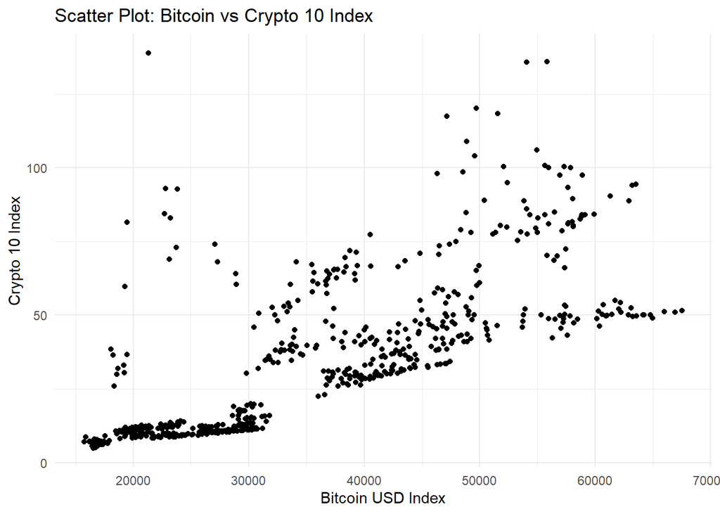

```r
#scatterplot between crypto10 index and Bitcoin
library(ggplot2)
BTC_Cryto10_plot <-
ggplot(merged_BTC_Cryto10, aes(x = Price.x, y = Price.y)) +
  geom_point() +
  labs(
    title = "Scatter Plot: Bitcoin vs Crypto 10 Index",
    x = "Bitcoin USD Index",
    y = "Crypto 10 Index"
  ) +
  theme_minimal()
BTC_Cryto10_plot
```

The scatter plot visually represents the relationship between the Bitcoin USD Index and the Crypto 10 Index. Each point on the plot corresponds to a specific date, and the position of the point indicates the value of Bitcoin on the X-axis and the value of the Crypto 10 Index on the Y-axis for that date.

From the plot, it is evident that there is a positive correlation between Bitcoin and the Crypto 10 Index. Points tend to cluster in an upward direction, suggesting that when Bitcoin’s value increases, the Crypto 10 Index also tends to increase, and vice versa. This positive correlation is consistent with the previously calculated correlation coefficient of 0.752, indicating a relatively strong relationship between the two indices.

This scatter plot provides a visual representation of the correlation between Bitcoin and the Crypto 10 Index, aiding in the interpretation of their price movements and relationship over time. It is a valuable tool for investors and analysts seeking to understand the dynamics between cryptocurrencies and broader cryptocurrency market indices.

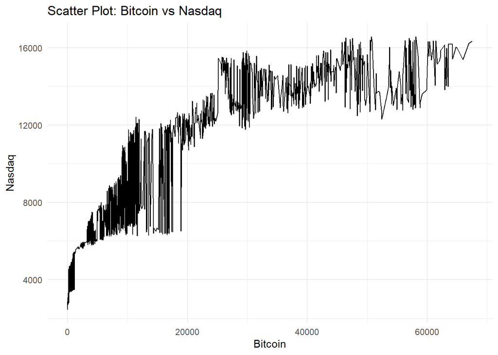

```r
#scatterplot between Nasdaq and Bitcoin
library(ggplot2)
BTC_Nasdaq_plot <-
ggplot(merged_BTC_Nasdaq, aes(x = Price.x, y = Price.y)) +
  geom_line() +
  labs(
    title = "Scatter Plot: Bitcoin vs Nasdaq",
    x = "Bitcoin",
    y = "Nasdaq"
  ) +
  theme_minimal()
BTC_Nasdaq_plot
```

The scatter plot provides an illustrative view of the relationship between Bitcoin and the Nasdaq Index. Each point on the plot corresponds to a specific date, with Bitcoin’s value on the X-axis and the Nasdaq Index’s value on the Y-axis for that date.

The plot shows a positive correlation between Bitcoin and the Nasdaq Index. Points on the plot tend to cluster in an upward direction, indicating that when Bitcoin’s value increases, the Nasdaq Index also tends to increase, and vice versa. This suggests that Bitcoin and the Nasdaq Index are positively related and that their price movements tend to be synchronized. The correlation coefficient of 0.90, calculated previously, supports this observation, indicating a strong positive correlation.

This scatter plot serves as a valuable visual tool for understanding the relationship between Bitcoin and the Nasdaq Index. It aids investors and analysts in interpreting how changes in Bitcoin’s value may impact the Nasdaq and vice versa. The positive correlation between these assets is essential knowledge for those interested in the cryptocurrency market and its relationship with traditional financial markets.

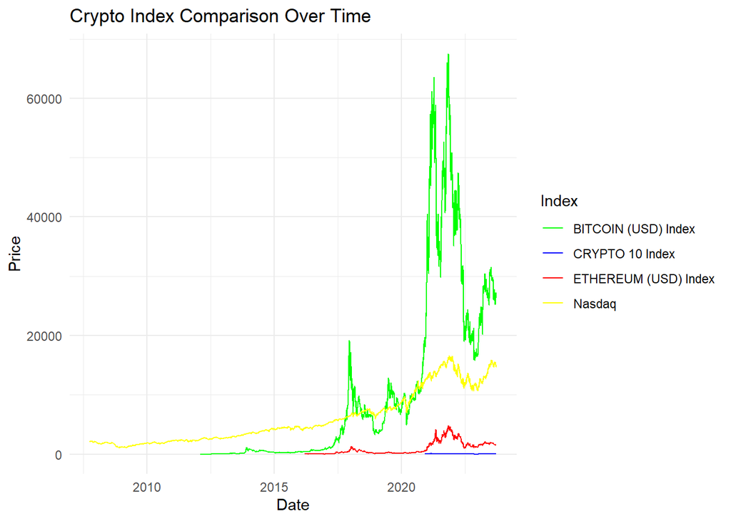

```r
#Overtimeplot between crypto10 index, Bitcoin and ethereum
BTC_Cryto10_ETHovertimePlot <-
ggplot() +
  geom_line(data = CR10.Index, aes(x = Date, y = Price, color = "CRYPTO 10 Index"), size = 0.5) +
  geom_line(data = BTC.Index, aes(x = Date, y = Price, color = "BITCOIN (USD) Index"), size = 0.5) +
  geom_line(data = ETH.Index, aes(x = Date, y = Price, color = "ETHEREUM (USD) Index"), size = 0.5) +
  geom_line(data = Nasdaq, aes(x = Date, y = Price, color = "Nasdaq"), size = 0.5) +
  labs(
    title = "Crypto Index Comparison Over Time",
    x = "Date",
    y = "Price",
    color = "Index"
  ) +
  scale_color_manual(values = c("CRYPTO 10 Index" = "Blue", "BITCOIN (USD) Index" = "Green", "ETHEREUM (USD) Index"="Red", "Nasdaq"="Yellow")) +
  theme_minimal()
BTC_Cryto10_ETHovertimePlot
```

This overtime plot provides a comprehensive view of the price movements of the Crypto 10 Index, Bitcoin (BTC), Ethereum (ETH), and the Nasdaq Index over time. Each line on the plot represents one of these financial assets, allowing for a visual comparison of their performance.

Crypto 10 Index: The Crypto 10 Index, depicted in blue, exhibits fluctuations in its price over the given time period. It reflects the overall performance of a basket of cryptocurrencies.

Bitcoin (BTC): The Bitcoin Index, shown in green, demonstrates its price variations. Bitcoin is a leading cryptocurrency and is known for its price volatility.

Ethereum (ETH): The Ethereum Index, presented in red, displays its price movements. Ethereum is another prominent cryptocurrency in the market.

Nasdaq: The Nasdaq Index, represented in yellow, showcases the price changes in the Nasdaq stock market index.

By comparing the movements of these different assets on a single plot, you can observe potential correlations or divergences in their price behavior over time. For instance, you can see if cryptocurrencies like Bitcoin and Ethereum move in sync with traditional financial markets like the Nasdaq.

```r
start_date <- as.Date("2020-01-01")
end_date <- as.Date("2023-12-31")
plot_eth_btc <- ggplot() +
  geom_line(data = BTC.Index, aes(x = Date, y = Price, color = "BITCOIN (USD) Index"), size = 0.5) +
  geom_line(data = ETH.Index, aes(x = Date, y = Price, color = "ETHEREUM (USD) Index"), size = 0.5)+
  labs(x = "Date", y = "Price") +
  scale_color_manual(values = c("BITCOIN (USD) Index" = "Green", "ETHEREUM (USD) Index"="Red")) + xlim(start_date,end_date)+
  ggtitle("Bitcoin and Etherium Price")
plot_crpto10 <- ggplot() +
  geom_line(data = CR10.Index, aes(x = Date, y = Price, color = "CRYPTO 10 Index"), size = 0.5) +
  labs(x = "Date", y = "Price") +
  scale_color_manual(values = c("CRYPTO 10 Index" = "Blue")) + xlim(start_date,end_date)
  ggtitle("Crypto10 Index")
```

```
## $title
## [1] "Crypto10 Index"
##
## attr(,"class")
## [1] "labels"
```

```r
grid.arrange(plot_eth_btc, plot_crpto10, ncol = 2)
plot(grid.arrange(plot_eth_btc, plot_crpto10, ncol = 2))
```

[output not shown]

# Question 4

### Q4

```r
library(knitr)
library(readr)
library(readxl)
library(magrittr)
library(dplyr)
```

```r
library(ggplot2)
library(gridExtra)
USDollar <- read_csv("US Dollar Index Historical Data.csv")
CrudeOil <- read_csv("Crude Oil WTI Futures Historical Data.csv")
Nat_Gas <- read_csv("Natural Gas Futures Historical Data.csv")
Gold <- read_csv("Gold Futures Historical Data.csv")
Silver <- read_csv("Silver Futures Historical Data.csv")
CrudeOil <- CrudeOil %>% mutate(Date = as.Date(Date, format = "%m/%d/%Y"))
Gold <- Gold %>% mutate(Date = as.Date(Date, format = "%m/%d/%Y"))
Nat_Gas <- Nat_Gas %>% mutate(Date = as.Date(Date, format = "%m/%d/%Y"))
Silver <- Silver %>% mutate(Date = as.Date(Date, format = "%m/%d/%Y"))
USDollar <- USDollar %>% mutate(Date = as.Date(Date, format = "%m/%d/%Y"))
```

The analysis of financial datasets often uncovers intriguing insights that extend beyond conventional financial metrics. In the context of commodities and currencies, outliers represent data points that stand apart from the norm. In this dataset encompassing different commodity varaibles, silver and natural gas emerge as the variables with the most outliers, showing a heightened susceptibility to extreme price fluctuations and market conditions that deviate from the typical patterns. Silver, a precious metal subject to influences ranging from economic data releases to geopolitical tensions, frequently experiences price swings. The multiple outliers suggest that silver prices can exhibit extraordinary shifts, raising questions about the drivers behind these exceptional movements. A similar narrative unfolds for natural gas, heavily influenced by supply and demand dynamics and energy market conditions. The notable number of outliers underscores the commodity’s propensity for significant deviations from the expected price range, sparking curiosity about the underlying causes.

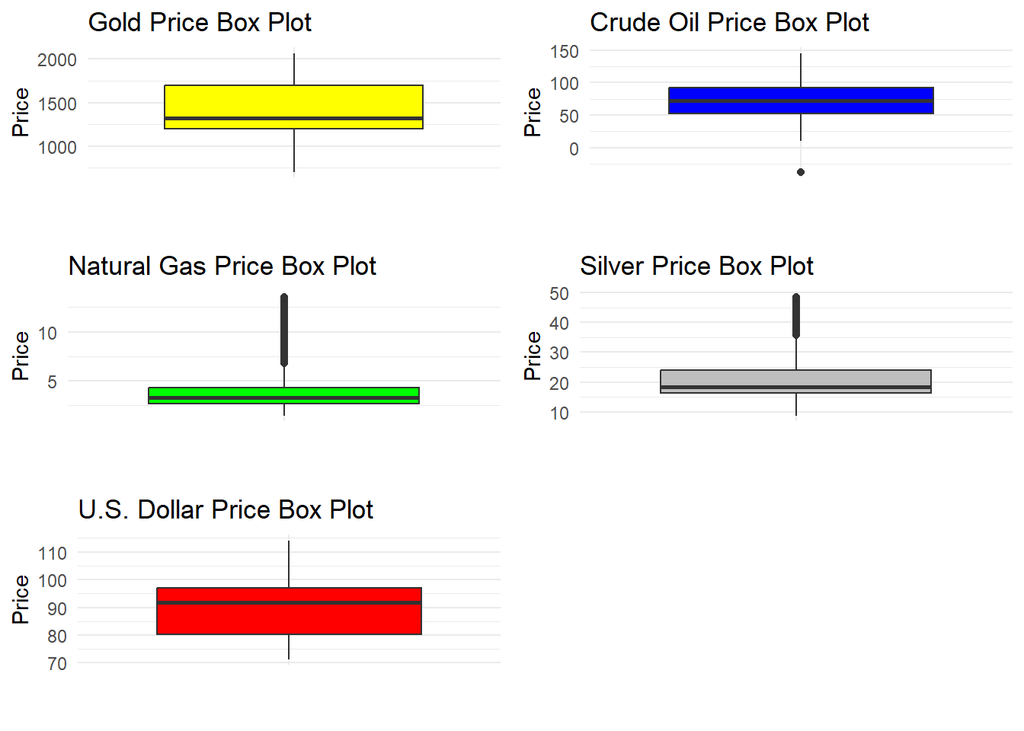

The dataset also reveals that crude oil, a critical energy commodity, demonstrates relatively fewer outliers. This observation suggests that crude oil maintains a more stable price range during the covered period. It’s indicative of the underlying factors and mechanisms governing the crude oil market, contributing to a smoother price variation compared to silver and natural gas. Understanding this differential behavior is crucial for us in order to manage risk effectively and make well-informed investment decisions. The recognition of outliers transcends numerical data points; it serves as a critical indicator in financial analysis. By investigating the nature and causes of these outliers, we gain deeper insights into the forces influencing these markets. This analysis enhances our ability to navigate the complexities of commodities and currencies, assess market volatility, and ultimately guiding more effective financial decision-making.

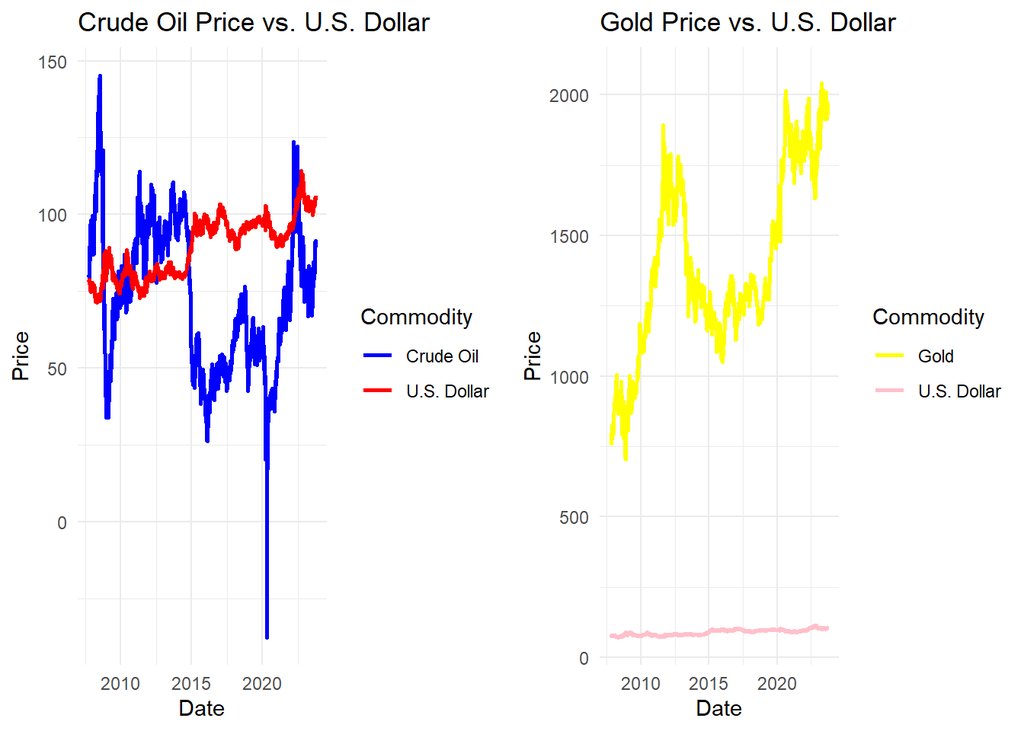

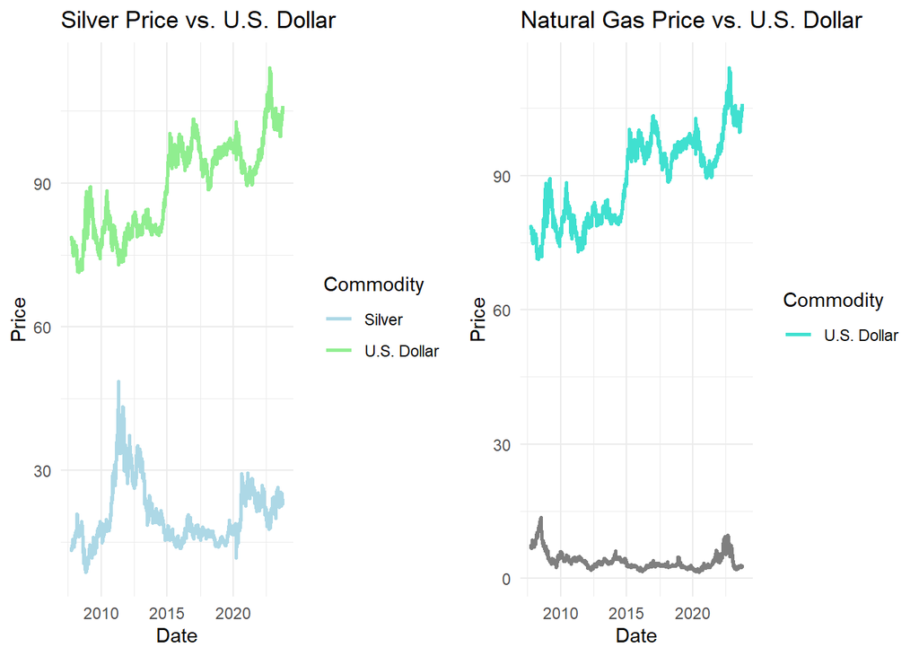

Moreover, the year 2020 serves as a noteworthy illustration of the broader market dynamics at play. During this period, the crude oil market experienced a significant downturn primarily due to the global COVID-19 pandemic. This event had profound implications for the energy sector, causing demand shocks, supply disruptions and impacting crude oil prices. The pandemic-induced market turmoil underscores the critical role that external events can play in influencing commodity prices, emphasizing the importance of considering broader economic and geopolitical factors in commodity analysis.

## Conclusion

In light of these findings, this analysis underscores the importance of understanding the multifaceted dynamics of global financial markets. It offers a roadmap to make informed investment decisions, implement effective risk management strategies, and identify opportunities for diversification in an ever-evolving financial landscape. The global financial system is a complex ecosystem where assets are interconnected, and events in one part of the world can reverberate across the globe. By unraveling these relationships, we empower investors, researchers, and market participants to navigate the financial landscape with a more profound understanding of its intricacies.